# Tree based latent variables correlation model

Anna Freni-Sterrantino, Denis Rustand, Janet van Niekerk, Elias T Krainski, and Hvard Rue

Started in November 2023, updated in May, 2026

```r
knitr::opts_chunk$set(
  echo = TRUE,
  message = FALSE,
  warning = FALSE,
  fig.width = 9,
  out.width = '0.49\\textwidth',
  fig.align = 'center')
library(graphpcor)
chinclude = TRUE
```

This material illustrate and detail the model properties of the graphical approach to model correlations proposed in Freni-Sterrantino et al. (2025). We first formalize the specific kind of graph used to define the model and provides an intuitive visualization. We use some examples for illustration and show how to implement the tree based correlation model proposed. We add details of the model definition at the end.

# The directed tree model definition

A graph is defined from a set of nodes and edges, where the nodes are linked by the edges. A directed acyclic graph consider directed edges linking the nodes. In the later case there is no closed loop. Yet, a tree is a graph where there is only one possible path between a pair of nodes. Furthermore, the edges of a tree are directed edges. This also impose a hierarchy on the nodes.

## The parents and children tree

We consider a particular tree definition where we have two different class of nodes to represent two kind of variables. We classify the nodes as parent or children. The nodes classified as children are leafs of the tree, which are nodes with an ancestor (parent) but with no children. The nodes classified as parent will always have children nodes, and some may have parent but will still be classified as parent because they have children. The directed edges (arrows) represent conditional distributions. At the end of this material we provide some detailed definition and examples.

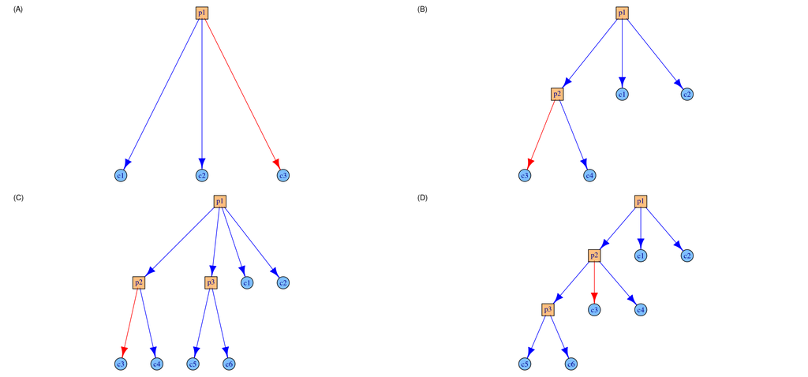

Graphs representing different models. A model with one parent, (A), a model with two parents (B), and two different models with three parents (C) and (D).

**NOTE**: The children variable `c3` is with a negative sign, assuming it has a negative correlation with the other children variables.

If a graph is used to represent conditional distributions, when computing the marginal distribution, it induces a the covariance between two nodes to be non-zero covariance as long as there is a path linking them in the graph. The same apply in our approach. Moreover, the strength of the correlation depends on how many parents, and their hierarchy, there is in the path linking them.

## The implied covariance

Let us represent the correlation between $a$ and $b$ as C(a,b). In the model defined with graph (A), |C($c_1$,$c_2$)| = |C($c_1$,$c_3$)| = |C($c_2$,$c_3$)|. From graph (B) |C($c_1$,$c_3$)| = |C($c_1,c_4$)| = |C($c_2$,$c_3$)| = |C($c_2$,$c_4$)| $\leq$ |C($c_1$,$c_2$)| $\leq$ |C($c_3$,$c_4$)|.

With the models defined from the graphs (C) and (D) we have |C($c_1$,$c_2$)|$\leq$|C($c_3$,$c_4$)|, |C($c_1$,$c_2$)|$\leq$|C($c_5$,$c_6$)|, and |C($c_1$,$c_3$)|=|C($c_1$,$c_4$)|= |C($c_2$,$c_3$)|=|C($c_2$,$c_4$)| and |C($c_1$,$c_5$)|=|C($c_1$,$c_6$)|= |C($c_2$,$c_5$)|=|C($c_2$,$c_6$)|. If we want to not fix the order between |C($c_3$,$c_4$)| and |C($c_5$,$c_6$) we can use the model from graph (C), whereas model (D) impose |C($c_3$,$c_4$)|$\leq$|C($c_5$,$c_6$)| and the correlation strength between a children of $p_3$ to a children of $p_1$ to be smaller than to a children of $p_2$, e.g. |C($c_1$,$c_5$)|$\leq$|C($c_3$,$c_5$)|.

These results follow from the application of the law of total expectation, variance and covariance. Let us start by having Var($p_j$) = $\gamma_j^2$ and the conditional variance for each children as Var($c_i$|$p_{c_i}$)=1. Thus, the marginal variance of $C_i$ is equal the sum of the variances of its ancestors plus 1.

# Illustrative code examples

In the environment we represent the parent variables with the letter `p` along with an integer number (`p1`, $\ldots$, `pk`) and the children variables with the letter `c` along with an integer number (`c1`, $\ldots$, `cm`). We adopt a simple way to specify the parent children representation. We consider the `~` (tilde) to represent the directed link and `+` (plus) or `-` (minus) to append the descendant to a parent. E.g.: `p1 ~ p2 + c1 + c2, p2 ~ c3 - c4` .

## Intial example

Let us consider a correlation model for three variables, with one parameter, that is the same absolute correlation between each pair but the sign may differ. This can be the case when these variables share the same latent factor. The parent is represented as `p1`, and the children variables as `c1`, `c2` and `c3`. We consider that `c3` will be negatively correlated with `c1` and `c2`. For this case we define the tree as

```r
tree1 <- treepcor(p1 ~ c1 + c2 - c3)
tree1
```

```
## treepcor for 3 children and 1 parent variables
## p1 ~ + c1 + c2 - c3
```

```r
summary(tree1)
```

```
##    p1
## c1  1
## c2  1
## c3 -1
```

where the summary shows their relationship. The number of children and parent variables are obtained with

```r
dim(tree1)
```

```
## children   parent
##        3        1
```

This tree can be visualized with

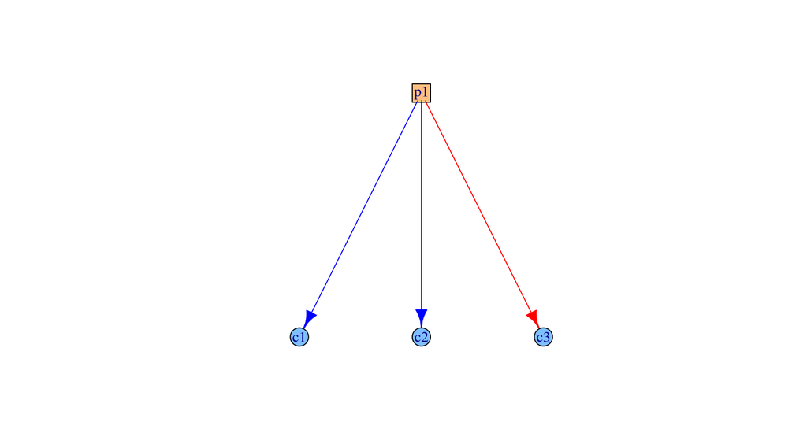

```r
plot(tree1)
```

From this model definition we will use the methods to build the correlation matrix. First, we build the precision matrix structure (that is not yet a precision matrix):

```r
tpcQ(tree1)
```

```
##    c1 c2 c3 p1
## c1  1  0  0 -1
## c2  0  1  0 -1
## c3  0  0  1  1
## p1 -1 -1  1  3
```

and we can use inform the log of $\gamma_1$, which is the standard error for $p_1$, with:

```r
q1 <- tpcQ(tree1, theta = 0)
q1
```

```
##    c1 c2 c3 p1
## c1  1  0  0 -1
## c2  0  1  0 -1
## c3  0  0  1  1
## p1 -1 -1  1  4
```

We can obtain the correlation matrix, which is our primarily interest, from the precision matrix. However, also have a covariance method to be directly applied with

```r
vcov(tree1) ## assume theta = 0 (\gamma_1 = 1)
```

```
##      c1   c2   c3
## c1  1.0  0.5 -0.5
## c2  0.5  1.0 -0.5
## c3 -0.5 -0.5  1.0
```

```r
vcov(tree1, theta = 0.5) # \gamma_1^2 = exp(2 * 0.5) = exp(1)
```

```
##            c1         c2         c3
## c1  1.0000000  0.7310586 -0.7310586
## c2  0.7310586  1.0000000 -0.7310586
## c3 -0.7310586 -0.7310586  1.0000000
```

```r
cov1a <- vcov(tree1, theta = 0)
cov1a
```

```
##      c1   c2   c3
## c1  1.0  0.5 -0.5
## c2  0.5  1.0 -0.5
## c3 -0.5 -0.5  1.0
```

from where we obtain the desired matrix with

```r
c1 <- cov2cor(cov1a)
round(c1, 3)
```

```
##      c1   c2   c3
## c1  1.0  0.5 -0.5
## c2  0.5  1.0 -0.5
## c3 -0.5 -0.5  1.0
```

## Correlation matrix with two parameters

In this example, we model the correlation between four variables using two parameters. We consider `c1` and `c2` having the same parent, `p1` and `c3` and `c4` having the second parent as parent. We want to have the correlation between `c3` and `c4` higher than the correlation between `c1` and `c3`. This requires `p2` to be children of `p1`. The tree for this is set by

```r
tree2 <- treepcor(
  p1 ~ p2 + c1 + c2,
  p2 ~ -c3 + c4)
dim(tree2)
```

```
## children   parent
##        4        2
```

```r
tree2
```

```
## treepcor for 4 children and 2 parent variables
## p1 ~ + p2 + c1 + c2
## p2 ~ - c3 + c4
```

```r
summary(tree2)
```

```
##    p1 p2
## c1  1  0
## c2  1  0
## c3  0 -1
## c4  0  1
## p2  1  0
```

which can be visualized by

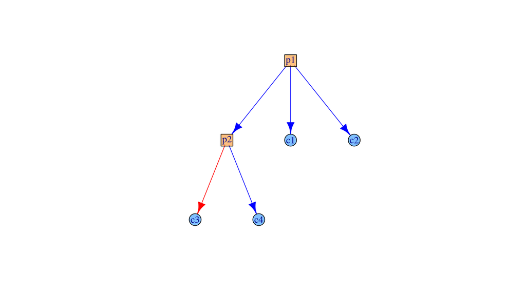

```r
plot(tree2)
```

We can use the `drop1` method to remove the last parent with

```r
drop1(tree2)
```

```
## treepcor for 4 children and 1 parent variables
## p1 ~ + c1 + c2 - c3 + c4
```

which align with the prior for the model parameters as proposed in Freni-Sterrantino et al. (2025). However, the code to implement such a prior is an internal C code and do not use this `drop1` which is fully a R code. In order to apply this for real data we do recommend to use the as shown further ahead in this vignette.

We now have two parameters: $\gamma_1^2$ the variance of $p_1$ and $\gamma_2^2$ the conditional variance of $p_2$. For $\gamma_1 = \gamma_2 = 1$, the precision matrix can be obtained with:

```r
q2 <- tpcQ(tree2, theta = c(0, 0))
q2
```

```
##    c1 c2 c3 c4 p1 p2
## c1  1  0  0  0 -1  0
## c2  0  1  0  0 -1  0
## c3  0  0  1  0  0  1
## c4  0  0  0  1  0 -1
## p1 -1 -1  0  0  4 -1
## p2  0  0  1 -1 -1  3
```

The correlation matrix can be obtained with

```r
cov2 <- vcov(tree2, theta = c(0, 0))
cov2
```

```
##            c1         c2         c3         c4
## c1  1.0000000  0.5000000 -0.4082483  0.4082483
## c2  0.5000000  1.0000000 -0.4082483  0.4082483
## c3 -0.4082483 -0.4082483  1.0000000 -0.6666667
## c4  0.4082483  0.4082483 -0.6666667  1.0000000
```

```r
c2 <- cov2cor(cov2)
round(c2, 3)
```

```
##        c1     c2     c3     c4
## c1  1.000  0.500 -0.408  0.408
## c2  0.500  1.000 -0.408  0.408
## c3 -0.408 -0.408  1.000 -0.667
## c4  0.408  0.408 -0.667  1.000
```

## Playing with sign

We can change the sign at any edge of the graph. The change in the edge of parent to children is simpler to interpret, as we can see in the covariance/correlation from the two examples.

```r
tree2b <- treepcor(
  p1 ~ -p2 + c1 + c2,
  p2 ~ -c3 + c4)
tree2b
```

```
## treepcor for 4 children and 2 parent variables
## p1 ~ - p2 + c1 + c2
## p2 ~ - c3 + c4
```

```r
summary(tree2b)
```

```
##    p1 p2
## c1  1  0
## c2  1  0
## c3  0 -1
## c4  0  1
## p2 -1  0
```

This gives the precision matrix as

```r
q2b <- tpcQ(tree2b, theta = c(0, 0))
q2b
```

```
##    c1 c2 c3 c4 p1 p2
## c1  1  0  0  0 -1  0
## c2  0  1  0  0 -1  0
## c3  0  0  1  0  0  1
## c4  0  0  0  1  0 -1
## p1 -1 -1  0  0  4  1
## p2  0  0  1 -1  1  3
```

```r
all.equal(solve(q2)[1:4, 1:4],
          solve(q2b)[1:4, 1:4])
```

```
## [1] "Mean relative difference: 2"
```

Therefore, allowing flexibility in an edge of parent to another parent is not useful and will only imply more complexity. Therefore we will not consider it in the `vcov` method.

**NOTE**: The `vcov` applied to a `treepcor` does not takes into account the sign between parent variables! So, please use it with care.

In case we just want to compute the raw covariance, assuming that V($p_j$)=1, to see the law of sum of for the four examples in Figure 1 we have

```r
vcov(tree1, raw = TRUE)
```

```
##    c1 c2 c3
## c1  2  1 -1
## c2  1  2 -1
## c3 -1 -1  2
```

```r
vcov(tree2, raw = TRUE)
```

```
##    c1 c2 c3 c4
## c1  2  1 -1  1
## c2  1  2 -1  1
## c3 -1 -1  3 -2
## c4  1  1 -2  3
```

```r
tree3a <- treepcor(p1 ~ p2 + p3 + c1 + c2,
                   p2 ~ -c3 + c4,
                   p3 ~ c5 + c6)
vcov(tree3a, raw = TRUE)
```

[output not shown]

```r
tree3b <- treepcor(p1 ~ p2 + c1 + c2,
                   p2 ~ p3 - c3 + c4,
                   p3 ~ c5 + c6)
vcov(tree3b, raw = TRUE)
```

```
##    c1 c2 c3 c4 c5 c6
## c1  2  1 -1  1  1  1
## c2  1  2 -1  1  1  1
## c3 -1 -1  3 -2 -2 -2
## c4  1  1 -2  3  2  2
## c5  1  1 -2  2  4  3
## c6  1  1 -2  2  3  4
```

**NOTE**: The `vcov` method for a `treepcor` without the `theta` argument assume $\gamma_j=1$ and $\sigma_i=1$. With not providing `raw` (or `raw = FALSE`) it will standardize the raw matrix then apply the $\sigma_i$.

# The penalized complexity prior

To implement the prior proposed in Freni-Sterrantino et al. (2025) we have used the `cgeneric` interface. First, let us define the model and its parameters. Let us consider the two parents example.

```r
tree2
```

```
## treepcor for 4 children and 2 parent variables
## p1 ~ + p2 + c1 + c2
## p2 ~ - c3 + c4
```

```r
(np <- dim(tree2))
```

```
## children   parent
##        4        2
```

Define the standard deviation parameters for the variables of interest

```r
sigmas <- c(4, 2, 1, 0.5)
```

and the log of the parent variance parameters

```r
thetal <- c(0, 1)
```

With that we can build the covariance with

```r
theta1 <- c(log(sigmas), thetal)
Vg <- vcov(tree2, theta = theta1)
Vg
```

```
##            c1         c2         c3         c4
## c1 16.0000000  4.0000000 -0.9230687  0.4615344
## c2  4.0000000  4.0000000 -0.4615344  0.2307672
## c3 -0.9230687 -0.4615344  1.0000000 -0.4467465
## c4  0.4615344  0.2307672 -0.4467465  0.2500000
```

Now we can simulate some data

```r
nrep <- 100
nd <- nrep * np[1]

xx <- matrix(rnorm(nd), nrep) %*% chol(Vg)
cov(xx)
```

```
##            c1          c2         c3          c4
## c1 17.2148854  4.65060952 -0.4507131  0.22182403
## c2  4.6506095  3.84445731 -0.0491233  0.05650542
## c3 -0.4507131 -0.04912330  0.7172700 -0.32757957
## c4  0.2218240  0.05650542 -0.3275796  0.20417978
```

```r
theta.y <- log(10)
datar <- data.frame(
    r = rep(1:nrep, np[1]),
    i = rep(1:np[1], each = nrep),
    y = rnorm(nd, 1 + xx, exp(-2*theta.y))
)
```

```r
cmodel <- cgeneric(
  tree2, lambda = 5,
  sigma.prior.reference = rep(1, np[1]),
  sigma.prior.probability = rep(0.05, np[1]))
```

The following code chunks require INLA installed.

Perform some checks (INLA is required):

```r
cgeneric_cgeneric_graph(cmodel)
cgeneric_initial(cmodel)
prior(cmodel, theta = rep(0, sum(np)))
prior(cmodel, theta = rep(1, sum(np)))

np
tpcQ(cmodel, theta = rep(0, sum(np)))
(Qc <- tpcQ(cmodel, theta = theta1))
all.equal(Vg, as.matrix(solve(Qc)))
```

Model fit (if have INLA installed)

```r
m1 <- y ~ f(i, model = cmodel, replicate = r)
pfix <- list(prec = list(initial = 10, fixed = TRUE))
fit <- inla(
    formula = m1,
    data = datar,
    control.family = list(hyper = pfix)
)
fit$cpu.used
```

Compare the true covariance, the observed covariance and the fitted covariance (from the posterior mode for theta)

```r
round(Vg, 2)
round(cov(xx), 2)
round(Vfit <- vcov(tree2, theta = fit$mode$theta), 2)
```

The fitted correlation (from posterior mode):

```r
round(Cfit <- vcov(tree2, theta = fit$mode$theta[np[1]+1:np[2]]), 2)
round(cov2cor(Vfit), 2)
```

# Model definition details

We now define a set of rules to propose a model. We assume a distribution for the main parent, $p_1$, and conditional distributions for each of the remaining $k-1$ parents and each of the $m$ children. The arrows represent each of these conditional distributions. Since we assume Gaussian distributions, we just need to define the (conditional) mean and variance.

- **1st rule**: For the main parent $p_1$, the mean is zero and the variance is $\gamma_1^2$.
- **2nd rule**: The conditional mean for $p_j$, $j=2$,…$k$, is its parent and the conditional variance is $\gamma_j^2$.
- **3rd rule**: The conditional mean of $c_i$, $i=1$, …, $m$, is $s_i$ times its parent and unit conditional variance, where $s_i$ is assumed known, either “-1” or “+1”.

We have $p$ parameters, one for each parent. These conditional distributions build up a joint one that will have a covariance matrix. Since we are primarily interested in the correlations, we will scale it by the implied variances and obtaining a correlation matrix. The marginal variances for each children are assigned after this scaling. As we will usually have $k<m$, this represents a reduction on the number of parameters, from $m(m+1)/2$ to $k+m$.

As an illustration, consider the graph (A) from Figure 1. The joint distribution for $\{c_1, c_2, c_3, p_1\}$ is
$$\pi(c_1, c_2, c_3, p_1) \propto \mathrm{exp}
\left\{-\frac{1}{2} \left[ \frac{p_1^2}{\gamma_1^2} +
\frac{(c_1-s_1p_1)^2}{s_1^2} + \frac{(c_2-s_2p_1)^2}{s_2^2} +
\frac{(c_3-s_3p_1)^2}{s_3^2} \right] \right\}.$$
From this set of conditional distributions we obtain the precision matrix as
$$\left[ \begin {array}{cccc}
{{\it s_1}}^{-2}&0&0&-{{\it s_1}}^{-1}\\
0&{{\it s_2}}^{-2}&0&-{{\it s_2}}^{-1}\\
0&0&{{\it s_3}}^{-2}&-{{\it s_3}}^{-1}\\
-{{\it s_1}}^{-1}&-{{\it s_2}}^{-1}&-{{\it
s_3}}^{-1}&{\gamma_1}^{-2}+3
\end {array} \right].$$

The joint distribution for $\{c_1, c_2, c_3, c_4, p_1, p_2\}$, from the DAG (B) in Figure 1, is proportional to
$$\mathrm{exp}
\left\{-\frac{1}{2} \left[ \frac{p_1^2}{\gamma_1^2} +
\frac{(p_2-p_1)^2}{\gamma_2^2} +
\frac{(c_1-s_1p_1)^2}{s_1^2} + \frac{(c_2-s_2p_1)^2}{s_2^2} +
\frac{(c_3-s_3p_2)^2}{s_3^2} + \frac{(c_4-s_4p_2)^2}{s_4^2} \right]
\right\}.$$
The precision matrix is
$$\left[ \begin {array}{cccccc}
{{\it s_1}}^{-2}&0&0&0&-{{\it s_1}}^{-1}&0\\
0&{{\it s_2}}^{-2}&0&0&-{{\it s_2}}^{-1}&0\\
0&0&{{\it s_3}}^{-2}&0&0&-{{\it s_3}}^{-1}\\
0&0&0&{{\it s_4}}^{-2}&0&-{{\it s_4}}^{-1}\\
-{{\it s_1}}^{-1}&-{{\it s_2}}^{-1}&0&0&
{\gamma_1}^{-2}+{\gamma_2}^{-2}+2&-{\gamma_2}^{-2}\\
0&0&-{{\it s_3}}^{-1}&-{{\it
s_4}}^{-1}&-{\gamma_2}^{-2}&{\gamma_2}^{-2}+2
\end {array} \right]$$

The models represented by graphs (C) and (D) in Figure 1 have both the same number of children and parents. The only difference is that parent $p_3$ is children to parent $p_1$ in (C) whereas in (D) $p_3$ is children to parent $p_2$. For the case when $p_1$ is parent to $p_3$ the precision matrix is
$$\left[ \begin {array}{ccccccccc}
{{\it s_1}}^{-2}&0&0&0&0&0&-{{\it
s_1}}^{-1}&0&0\\
0&{{\it s_2}}^{-2}&0&0&0&0&-{{\it
s_2}}^{-1}&0&0\\
0&0&{{\it s_3}}^{-2}&0&0&0&0&-{{\it
s_3}}^{-1}&0\\
0&0&0&{{\it s_4}}^{-2}&0&0&0&-{{\it
s_4}}^{-1}&0\\
0&0&0&0&{{\it s_5}}^{-2}&0&0&0&-{{\it
s_5}}^{-1} \\
0&0&0&0&0&{{\it s_6}}^{-2}&0&0&-{{\it
s_6}}^{-1}\\
-{{\it s_1}}^{-1}&-{{\it s_2}}^{-1}&0&0&0&0&
{\gamma_1}^{-2}+{\gamma_2}^{-2}+{\gamma_3}^{-2} +2 &
-{\gamma_2}^{-2}&-{\gamma_3}^{-2}\\
0&0&-{{\it s_3}}^{-1}&-{{\it s_4}}^{-1}&0&0&
-{\gamma_2}^{-2}&{\gamma_2}^{-2}+2&0\\
0&0&0&0&-{{\it s_5}}^{-1}&-{{\it s_6}}^{-1}&
-{\gamma_3}^{-2}&0&{\gamma_3}^{-2}+2
\end {array} \right]$$
and the case when $p_2$ is parent to $p_3$ the last three rows of the precision matrix are
$$\left[ \begin {array}{ccccccccc}
-{{\it s_1}}^{-1}&-{{\it
s_2}}^{-1}&0&0&0&0&{\gamma_1}^{-2}+{\gamma_2}^{-2}+2&-{\gamma_2}^{-2}
&0\\ 0&0&-{{\it s_3}}^{-1}&-{{\it
s_4}}^{-1}&0&0&-{\gamma_2}^{-2}&{\gamma_2}^{-2}+{\gamma_3}^{-2}+2&-{\gamma_3}^{-2}\\
0&0&0&0&-{{\it s_5}}^{-1}&-{
{\it s_6}}^{-1}&0&-{\gamma_3}^{-2}&{\gamma_3}^{-2}+2\end
{array} \right]$$
and the first $6$ rows are equal the ones from the previous case.

## Model properties

The conditional distributions defines a precision matrix for all the $m+k$ variables in the model and a joint distribution. Therefore we can obtain the implied covariance matrix to learn the marginal properties, and correlations as well. Since our primarily interest is in the correlation between the children variables, we consider its first $m$ rows and columns.

The model defined from the DAG (A) in Figure 1 for $\{c_1, c_2, c_3, p_1\}$ induces a covariance matrix equals to
$$\left[ \begin {array}{cccc}
( 1+{\gamma_1}^{2} ) {{\it s_1}}^{2} & {\it s_2}{\it
s_1}{\gamma_1}^{2}&
{\it s_3}{\it s_1}{\gamma_1}^{2} & {\it s_1}{\gamma_1}^{2} \\
{\it s_2}{\it s_1}{\gamma_1}^{2} & ( 1+{\gamma_1}^{2} ) {{\it
s_2}}^{2}&
{\it s_3}{\it s_2}{\gamma_1}^{2} & {\it s_2}{\gamma_1}^{2} \\
{\it s_3}{\it s_1}{\gamma_1}^{2} &{\it s_3}{\it
s_2}{\gamma_1}^{2}&
( 1+{\gamma_1}^{2} ) {{\it s_3}}^{2} & {\it s_3}{\gamma_1}^{2} \\
{\it s_1}{\gamma_1}^{2} & {\it s_2}{\gamma_1}^{2} &
{\it s_3}{\gamma_1}^{2}&{\gamma_1}^{2}
\end {array} \right]$$
and the C($c_i,c_j$) = sign($s_is_j$)$\gamma_1^2/(1+\gamma_1^2)$, for $i,j\in\{1,2,3\}$ and $i\neq j$.

The model defined from the DAG (B) in Figure 1 gives the covariance matrix for $\{c_1, c_2, c_3, c_4, p_1, p_2\}$ as
$$\left[ \begin {array}{cccccc} \left( 1+{\gamma_1}^{2} \right) {{\it
s_1}}^{2}&{\it s_2}\,{\gamma_1}^{2}{\it s_1}&{\it
s_3}\,{\gamma_1}^{2}{\it s_1}&{\it s_4}\,{\gamma_1}^{2}{\it
s_1}&{\gamma_1}^{2}{\it s_1}&{\gamma_1}^{2}{\it s_1}\\ {\it
s_2}\,{\gamma_1}^{2}{\it s_1}& \left( 1+{\gamma_1}^{2} \right) {{\it
s_2}}^{2}&{\it s_3}\,{\gamma_1
}^{2}{\it s_2}&{\it s_4}\,{\gamma_1}^{2}{\it
s_2}&{\gamma_1}^{2}{\it s_2}&{\gamma_1}^{2}{\it s_2}\\ {\it
s_3}\,{\gamma_1}^{2}{\it s_1}&{\it s_3}\,{\gamma_1}^{
2}{\it s_2}& \left( 1+{\gamma_2}^{2}+{\gamma_1}^{2} \right) {{\it
s_3}}^{2}&{\it s_4}\, \left( {\gamma_2}^{2}+{\gamma_1}^{2} \right)
{\it s_3}&{\gamma_1}^{2}{\it s_3}& \left( {{
\it \gamma_2}}^{2}+{\gamma_1}^{2} \right) {\it s_3}\\ {\it
s_4}\,{\gamma_1}^{2}{\it s_1}&{\it s_4}\,{\gamma_1}^{2}{\it
s_2}&{\it s_4}\, \left( {\gamma_2}^{2}+{{\it
\gamma_1}}^{2} \right) {\it s_3}& \left(
1+{\gamma_2}^{2}+{\gamma_1}^{2} \right) {{\it
s_4}}^{2}&{\gamma_1}^{2}{\it s_4}& \left(
{\gamma_2}^{2}+{\gamma_1}^{2} \right) {\it s_4}
\\ {\gamma_1}^{2}{\it s_1}&{\gamma_1}^{2}{\it
s_2}&{\gamma_1}^{2}{\it s_3}&{\gamma_1}^{2}{\it
s_4}&{\gamma_1}^{2}&{\gamma_1}^{2}\\ {\gamma_1
}^{2}{\it s_1}&{\gamma_1}^{2}{\it s_2}& \left(
{\gamma_2}^{2}+{\gamma_1}^{2} \right) {\it s_3}& \left(
{\gamma_2}^{2}+{\gamma_1}^{2} \right) {\it
s_4}&{\gamma_1}^{2}&{\gamma_2}
^{2}+{\gamma_1}^{2}\end {array} \right]$$
from what the marginal properties can be learn. The upper triangle of the children correlation matrix is
$$\left[ \begin {array}{ccc}
\frac{\textrm{sign}(s_1s_2){\gamma_1}^{2}}{{( {\gamma_1}^{2}+1 )}} &
\frac{\textrm{sign}(s_1 s_3){\gamma_1}^{2}} {\sqrt{( {\gamma_1}^{2}+1 )}
\sqrt { ( 1+{\gamma_2}^{2}+{\gamma_1}^{2} )}} &
\frac{\textrm{sign}(s_1 s_4){\gamma_1}^{2}} {\sqrt{( {\gamma_1}^{2}+1 )}
\sqrt { ( 1+{\gamma_2}^{2}+{\gamma_1}^{2} )}}\\
& \frac{\textrm{sign}(s_2 s_3){\gamma_1}^{2}} {\sqrt{(
{\gamma_1}^{2}+1 )} \sqrt { ( 1+{\gamma_2}^{2}+{\gamma_1}^{2} )}} &
\frac{\textrm{sign}(s_2 s_4){\gamma_1}^{2}} {\sqrt{( {\gamma_1}^{2}+1 )}
\sqrt { ( 1+{\gamma_2}^{2}+{\gamma_1}^{2} )}}\\
& & \frac{{\textrm{sign}(s_3 s_4) (
{\gamma_2}^{2}+{\gamma_1}^{2}) }}{
{( 1+{\gamma_2}^{2}+{\gamma_1}^{2})}}
\end{array} \right]$$
where C($s_i,s_j$) = sign($s_is_j$)$\frac{\gamma_1^2}{(\gamma_1^2+1)(1+\gamma_1^2+\gamma_2^2)}$ for $i\in\{1,2\}$ and $j\in\{3,4\}$, which defines a block with the same absolute value and is the main structure that this model induced for the correlation matrix.

In the model given from graph (C), when $p_1$ is parent to $p_3$, the covariance matrix of $\{c_1,...,c_6\}$ is
$$\scriptsize
\left[ \begin {array}{cccccc} \left( 1+{\gamma_1}^{2} \right) {{\it
s_1}}^{2}&{\it s_2}\,{\gamma_1}^{2}{\it s_1}&{\it
s_3}\,{\gamma_1}^{2}{\it s_1}&{\it s_4}\,{\gamma_1}^{2}{\it
s_1}&{\it s_5}\,{\gamma_1}^{2}{\it s_1}&{\it
s_6}\,{\gamma_1}^{2}{\it s_1}\\ {\it s_2}\,{\gamma_1}^{2}{\it s_1}&
\left( 1+{\gamma_1}^{2} \right) {{\it s_2}}^{2}
&{\it s_3}\,{\gamma_1}^{2}{\it s_2}&{\it
s_4}\,{\gamma_1}^{2}{\it s_2}&{\it s_5}\,{\gamma_1}^{2}{\it
s_2}&{\it s_6}\,{\gamma_1}^{2}{\it s_2}\\ {\it s_3}\,{{
\it \gamma_1}}^{2}{\it s_1}&{\it s_3}\,{\gamma_1}^{2}{\it s_2}&
\left( 1+{\gamma_2}^{2}+{\gamma_1}^{2} \right) {{\it s_3}}^{2}&{\it
s_4}\, \left( {\gamma_2}^{2}+{\gamma_1}^{2}
\right) {\it s_3}&{\it s_5}\,{\gamma_1}^{2}{\it s_3}&{\it
s_6}\,{\gamma_1}^{2}{\it s_3}\\ {\it s_4}\,{\gamma_1}^{2}{\it
s_1}&{\it s_4}\,{\gamma_1}^{2}{\it s_2
}&{\it s_4}\, \left( {\gamma_2}^{2}+{\gamma_1}^{2} \right) {\it
s_3}& \left( 1+{\gamma_2}^{2}+{\gamma_1}^{2} \right) {{\it
s_4}}^{2}&{\it s_5}\,{\gamma_1}^{2}{\it s_4}&{\it s_6}
\,{\gamma_1}^{2}{\it s_4}\\ {\it s_5}\,{\gamma_1}^{2}{\it s_1}&{\it
s_5}\,{\gamma_1}^{2}{\it s_2}&{\it s_5}\,{\gamma_1}^{2}{\it
s_3}&{\it s_5}\,{\gamma_1}^{2}
{\it s_4}& \left( 1+{\gamma_3}^{2}+{\gamma_1}^{2} \right) {{\it
s_5}}^{2}&{\it s_6}\,{\it s_5}\, \left(
{\gamma_3}^{2}+{\gamma_1}^{2} \right) \\ {\it s_6}\,{{\it
\gamma_1}}^{2}{\it s_1}&{\it s_6}\,{\gamma_1}^{2}{\it s_2}&{\it
s_6}\,{\gamma_1}^{2}{\it s_3}&{\it s_6}\,{\gamma_1}^{2}{\it
s_4}&{\it s_6}\,{\it s_5}\, \left( {\gamma_3}^{2}+{{\it
\gamma_1}}^{2} \right) & \left( 1+{\gamma_3}^{2}+{\gamma_1}^{2}
\right) {{\it s_6}}^{2}\end {array} \right]$$
where the variances and covariance for $c_5$ and $c_6$ does not depends on $\gamma_2^2$.

For the case when $p_2$ is parent to $p_3$ the covariance of $c_1$, …, $c_6$ is
$$\tiny
\left[ \begin {array}{cccccc} \left( 1+{\gamma_1}^{2} \right) {{\it
s_1}}^{2}&{\it s_2}\,{\gamma_1}^{2}{\it s_1}&{\it
s_3}\,{\gamma_1}^{2}{\it s_1}&{\it s_4}\,{\gamma_1}^{2}{\it
s_1}&{\it s_5}\,{\gamma_1}^{2}{\it s_1}&{\it
s_6}\,{\gamma_1}^{2}{\it s_1}\\ {\it s_2}\,{\gamma_1}^{2}{\it s_1}&
\left( 1+{\gamma_1}^{2} \right) {{\it s_2}}^{2}
&{\it s_3}\,{\gamma_1}^{2}{\it s_2}&{\it
s_4}\,{\gamma_1}^{2}{\it s_2}&{\it s_5}\,{\gamma_1}^{2}{\it
s_2}&{\it s_6}\,{\gamma_1}^{2}{\it s_2}\\ {\it s_3}\,{{
\it \gamma_1}}^{2}{\it s_1}&{\it s_3}\,{\gamma_1}^{2}{\it s_2}&
\left( 1+{\gamma_2}^{2}+{\gamma_1}^{2} \right) {{\it s_3}}^{2}&{\it
s_4}\, \left( {\gamma_2}^{2}+{\gamma_1}^{2}
\right) {\it s_3}&{\it s_5}\, \left( {\gamma_2}^{2}+{\gamma_1}^{2}
\right) {\it s_3}&{\it s_6}\, \left( {\gamma_2}^{2}+{\gamma_1}^{2}
\right) {\it s_3}\\ {\it
s_4}\,{\gamma_1}^{2}{\it s_1}&{\it s_4}\,{\gamma_1}^{2}{\it
s_2}&{\it s_4}\, \left( {\gamma_2}^{2}+{\gamma_1}^{2} \right) {\it
s_3}& \left( 1+{\gamma_2}^{2}+{\gamma_1}^{2}
\right) {{\it s_4}}^{2}&{\it s_5}\, \left(
{\gamma_2}^{2}+{\gamma_1}^{2} \right) {\it s_4}&{\it s_6}\, \left(
{\gamma_2}^{2}+{\gamma_1}^{2} \right) {\it s_4}\\ {
\it s_5}\,{\gamma_1}^{2}{\it s_1}&{\it s_5}\,{\gamma_1}^{2}{\it
s_2}&{\it s_5}\, \left( {\gamma_2}^{2}+{\gamma_1}^{2} \right) {\it
s_3}&{\it s_5}\, \left( {\gamma_2}^{2}+{{\it
\gamma_1}}^{2} \right) {\it s_4}& \left(
1+{\gamma_3}^{2}+{\gamma_2}^{2}+{\gamma_1}^{2} \right) {{\it
s_5}}^{2}&{\it s_6}\,{\it s_5}\, \left(
{\gamma_3}^{2}+{\gamma_2}^{2}+{\gamma_1}
^{2} \right) \\ {\it s_6}\,{\gamma_1}^{2}{\it s_1}&{\it
s_6}\,{\gamma_1}^{2}{\it s_2}&{\it s_6}\, \left(
{\gamma_2}^{2}+{\gamma_1}^{2} \right) {\it s_3}&{\it s_6
}\, \left( {\gamma_2}^{2}+{\gamma_1}^{2} \right) {\it s_4}&{\it
s_6}\,{\it s_5}\, \left( {\gamma_3}^{2}+{\gamma_2}^{2}+{\gamma_1}^{2}
\right) & \left( 1+{\gamma_3}^{2}+{\gamma_2
}^{2}+{\gamma_1}^{2} \right) {{\it s_6}}^{2}\end {array} \right]$$
where the variances and covariance for $c_5$ and $c_6$ now depends on $\gamma_2^2$.

For the correlations, we now compare C($c_i,c_j$), for $i\neq j$ and $i,j\in\{3,4,5,6\}$, with these two different models. The upper triangle of the correlation matrix for $c_3$, …, $c_6$ obtained with the model where $p_1$ is parent to $p_3$ is
$$\left[ \begin {array}{ccc}
\textrm{sign}(s_3s_4)\frac{\gamma_1^2+\gamma_2^2}{1+\gamma_1^2+\gamma_2^2}
&
\textrm{sign}(s_3s_5)\frac{\gamma_1^2}{\sqrt{(1+\gamma_1^2)(1+\gamma_1^2+\gamma_3^2)}}
&
\textrm{sign}(s_3s_6)\frac{\gamma_1^2}{\sqrt{(1+\gamma_1^2)(1+\gamma_1^2+\gamma_3^2)}}
\\
&
\textrm{sign}(s_4s_5)\frac{\gamma_1^2}{\sqrt{(1+\gamma_1^2)(1+\gamma_1^2+\gamma_3^2)}}
&
\textrm{sign}(s_4s_6)\frac{\gamma_1^2}{\sqrt{(1+\gamma_1^2)(1+\gamma_1^2+\gamma_3^2)}}
\\
& & \textrm{sign}(s_5s_6)\frac{\gamma_1^2 +
\gamma_3^2}{\sqrt{(1+\gamma_1^2+\gamma_3^2)}} \\
\end{array} \right],$$
and with the model when $p_2$ is parent to $p_3$ it is
$$\left[ \begin {array}{ccc}
\textrm{sign}(s_3s_4)\frac{\gamma_1^2+\gamma_2^2}{1+\gamma_1^2+\gamma_2^2}
&
\textrm{sign}(s_3s_5)\frac{\gamma_1^2+\gamma_2^2}{\sqrt{(1+\gamma_1^2+\gamma_2^2)(1+\gamma_1^2+\gamma_3^2)}}
&
\textrm{sign}(s_3s_6)\frac{\gamma_1^2+\gamma_2^2}{\sqrt{(1+\gamma_1^2+\gamma_2^2)(1+\gamma_1^2+\gamma_3^2)}}
\\
&
\textrm{sign}(s_4s_5)\frac{\gamma_1^2+\gamma_2^2}{\sqrt{(1+\gamma_1^2+\gamma_2^2)(1+\gamma_1^2+\gamma_3^2)}}
&
\textrm{sign}(s_4s_6)\frac{\gamma_1^2+\gamma_2^2}{\sqrt{(1+\gamma_1^2+\gamma_2^2)(1+\gamma_1^2+\gamma_3^2)}}
\\
& &
\textrm{sign}(s_5s_6)\frac{\gamma_1^2+\gamma_2^2+\gamma_3^2}{1+\gamma_1^2+\gamma_2^2+\gamma_3^2}
\\
\end{array} \right].$$
Comparing these results, when $p_1$ is parent to $p_3$ there is no contribution from $\gamma_2^2$ in C($c_5,c_6$) and neither in C($c_i,c_j$), for $i\in\{3,4\}$, whereas when $p_2$ is parent to $p_3$ there is.

From these examples we can list a set of properties as follows.

- **Property 1**: The marginal variance of $p_i$ is $\gamma_i^2$ plus the variance of its parent.
  - **Property 1a**: For $p_1$ it is equal its conditional variance, $\gamma_1^2$.
  - **Property 1b**: The marginal variance of $p_i$ is $\gamma_i^2$ plus the conditional variance of its ancestors.
- **Property 2**: The marginal variance of $c_i$ is equal $s_i^2(1+V)$, where $V$ is the variance of its parent.
- **Property 3**: The covariance between $c_i$ and $c_j$ is equal $s_is_jR$, where $R$ is the variance of the top indexed parent in the path linking them.
  - **Property 3a**: If $c_i$ and $c_j$ have a common parent, $R$ is the variance of their parent.
- **Property 4**: C($c_i,c_j$)=sign($s_is_j$)R/$\sqrt{\gamma_{c_i}\gamma_{c_j}}$, where $\gamma_{c_i}$ and $\gamma_{c_j}$ are the marginal variances of $c_i$ and $c_j$, respectively.
  - **Property 4a**: If $c_i$ and $c_j$ have a common parent, the correlation is sign($s_is_j$)$V/(1+V)$ where $V$ is the variance of their parent.
- **Property 5**: Let $k_0$ be the number of parents with no children variable as children, $k_1$ be the number of parents with one children variable as children, and $k_2$ be the number of parents with at least two children variables as children. The number of distinct absolute correlation values is $k_2+(k_1-k_0)(k_1-k_0-1)/2$.
  - **Property 5a**: If each parent variable has only one children variable as children, this number is $k(k-1)/2$.
  - **Property 5b**: The maximum number of distinct absolute correlation values is $k(k+1)/2$, achieved if each parent variable is parent to at least two children variables.

This intuitive modeling approach gives way to build a structured correlation matrix. The number of distinct absolute correlation values is $k(k+1)/2$. The sign assumed for each arrow ending at a children variable allows the full range of the correlation values, from $-1$ to $1$. Prior distributions can be considered for the marginal variances and for the correlation matrix separately.

## A further example

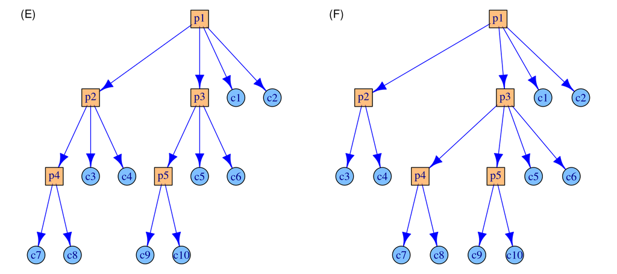

Two different models for the same number of children and parents.

The model for the DAG in (E) gives a precision matrix whose last five columns are
$$\scriptsize
\left[ \begin {array}{ccccc} -{{\it s_1}}^{-1}&0&0&0&0\\
-{{\it s_2}}^{-1}&0&0&0&0\\ 0&-{{\it
s_3}}^{-1}&0&0&0\\ 0&-{{\it s_4}}^{-1}&0&0
&0\\ 0&0&-{{\it s_5}}^{-1}&0&0\\ 0&0&-{{\it
s_6}}^{-1}&0&0\\ 0&0&0&-{{\it s_7}}^{-1}&0\\
0&0&0&-{{\it s_8}}^{-1}&0
\\ 0&0&0&0&-{{\it s_9}}^{-1}\\
0&0&0&0&-{{\it s_{10}}}^{-1}\\
{\gamma_1}^{-2}+2+{\gamma_2}^{-2}+{\gamma_3}^{-2}&-{\gamma_2}^{-2}&-{{
\it \gamma_3}}^{-2}&0&0\\
-{\gamma_2}^{-2}&{\gamma_2}^{-2}+2+{\gamma_4}^{-2}&0&-{\gamma_4}^{-2}&0\\
-{\gamma_3}^{-2}&0&{\gamma_3}^{-2}+2+{\gamma_5}^
{-2}&0&-{\gamma_5}^{-2}\\
0&-{\gamma_4}^{-2}&0&{\gamma_4}^{-2}+2&0\\
0&0&-{\gamma_5}^{-2}&0&{\gamma_5}^{-2}+2\end {array}
\right]$$
while the last five columns for the precision matrix for the model for DAG in (F) are
$$\scriptsize
\left[ \begin {array}{ccccc}
-{{\it s_1}}^{-1}&0&0&0&0\\ -{{\it
s_2}}^{-1}&0&0&0&0\\ 0&-{{\it
s_3}}^{-1}&0&0&0\\ 0&-{{\it s_4}}^{-1}&0&0
&0\\ 0&0&-{{\it s_5}}^{-1}&0&0\\ 0&0&-{{\it
s_6}}^{-1}&0&0\\ 0&0&0&-{{\it s_7}}^{-1}&0\\
0&0&0&-{{\it s_8}}^{-1}&0
\\ 0&0&0&0&-{{\it s_9}}^{-1}\\
0&0&0&0&-{{\it s_{10}}}^{-1}\\
{\gamma_1}^{-2}+2+{\gamma_2}^{-2}+{\gamma_3}^{-2}&-{\gamma_2}^{-2}&-{{
\it \gamma_3}}^{-2}&0&0\\
-{\gamma_2}^{-2}&{\gamma_2}^{-2}+2&0&0&0\\
-{\gamma_3}^{-2}&0&{\gamma_3}^{-2}+2+{\gamma_4}^{-2}+{\gamma_5}^{-2}&-{\gamma_4
}^{-2}&-{\gamma_5}^{-2}\\
0&0&-{\gamma_4}^{-2}&{\gamma_4}^{-2}+2&0\\
0&0&-{\gamma_5}^{-2}&0&{\gamma_5}^{-2}+2
\end {array} \right]$$

To illustrate property about the top parent on a path, we consider the upper triangle of the correlation matrix for the last four children variables, $c_7,...,c_{10}$. For the model defined from (E) we have it as
$$\left[ \begin {array}{ccc}
{\frac { \textrm{sign}({\it s_7 s_8}) (
{\gamma_1}^{2}+{\gamma_2}^{2}+{\gamma_4}^{2} )}{(
1+{\gamma_1}^{2}+{\gamma_2}^{2}+{\gamma_4}^{2} )}} &
\frac {\textrm{sign}({\it s_7 s_9}) {\gamma_1}^{2}}{\sqrt { (
1+{\gamma_1}^{2}+{\gamma_2}^{2}+{\gamma_4}^{2} ) (
1+{\gamma_1}^{2}+{\gamma_3}^{2}+{\gamma_5}^{2} )}} &
\frac {\textrm{sign}({\it s_7 s_{10}}) {\gamma_1}^{2}}{\sqrt { (
1+{\gamma_1}^{2}+{\gamma_2}^{2}+{\gamma_4}^{2} ) (
1+{\gamma_1}^{2}+{\gamma_3}^{2}+{\gamma_5}^{2} )}} \\
& \frac {\textrm{sign}({\it s_8 s_9}) {\gamma_1}^{2}}{\sqrt { (
1+{\gamma_1}^{2}+{\gamma_2}^{2}+{\gamma_4}^{2} ) (
1+{\gamma_1}^{2}+{\gamma_3}^{2}+{\gamma_5}^{2} )}} &
\frac {\textrm{sign}({\it s_8 s_{10}}) {\gamma_1}^{2}}{\sqrt { (
1+{\gamma_1}^{2}+{\gamma_2}^{2}+{\gamma_4}^{2} ) (
1+{\gamma_1}^{2}+{\gamma_3}^{2}+{\gamma_5}^{2} )}}\\
& & \frac { \textrm{sign}({\it s_{9} s_{10}}) (
{\gamma_1}^{2}+{\gamma_3}^{2}+{\gamma_5}^{2} ) }{\sqrt { (
1+{\gamma_1}^{2}+{\gamma_3}^{2}+{\gamma_5}^{2} ) }} \\
\end {array} \right]$$
where C($c_i,c_j$), for $i\in\{7,8\}$ and $j\in\{9,10\}$ increase depends only on $\gamma_1^2$ and depends on all $\gamma_j^2$ for $j=\{1,\ldots,5\}$. With the model defined from (F) we have
$$\
\left[ \begin {array}{ccc}
\frac {\textrm{sign}({\it s_7s_8}) (
{\gamma_1}^{2}+{\gamma_3}^{2}+{\gamma_4}^{2} ) }{(
1+{\gamma_1}^{2}+{\gamma_3}^{2}+{\gamma_4}^{2} ) } &
\frac { \textrm{sign}({\it s_7s_9}) ( {\gamma_1}^{2}+{\gamma_3}^{2} )
}{\sqrt { ( 1+{\gamma_1}^{2}+{\gamma_3}^{2}+{\gamma_4}^{2} ) (
1+{\gamma_1}^{2}+{\gamma_3}^{2}+{\gamma_5}^{2} ) }} &
\frac { \textrm{sign}({\it s_7s_{10}}) ( {\gamma_1}^{2}+{\gamma_3}^{2} )
}{\sqrt { ( 1+{\gamma_1}^{2}+{\gamma_3}^{2}+{\gamma_4}^{2} ) (
1+{\gamma_1}^{2}+{\gamma_3}^{2}+{\gamma_5}^{2} ) }} \\
& \frac { \textrm{sign}({\it s_9s_9}) (
{\gamma_1}^{2}+{\gamma_3}^{2} ) }{\sqrt { (
1+{\gamma_1}^{2}+{\gamma_3}^{2}+{\gamma_4}^{2} ) (
1+{\gamma_1}^{2}+{\gamma_3}^{2}+{\gamma_5}^{2} ) }} &
\frac { \textrm{sign}({\it s_8s_{10}}) ( {\gamma_1}^{2}+{\gamma_3}^{2} )
}{\sqrt { ( 1+{\gamma_1}^{2}+{\gamma_3}^{2}+{\gamma_4}^{2} ) (
1+{\gamma_1}^{2}+{\gamma_3}^{2}+{\gamma_5}^{2} ) }} \\
& & \frac {\textrm{sign}({\it s_9s_{10}}) (
{\gamma_1}^{2}+{\gamma_3}^{2}+{\gamma_5}^{2} ) }{ (
1+{\gamma_1}^{2}+{\gamma_3}^{2}+{\gamma_5}^{2} )}
\end {array} \right]$$
where now C($c_i,c_j$), for $i\in\{7,8\}$ and $j\in\{9,10\}$, increases if $\gamma_1^2+\gamma_3^2$ (the variance of $p_3$) increases and no longer depends on $\gamma_2^2$.

# References

Freni-Sterrantino, Anna, Denis Rustand, Janet van Niekerk, Elias T. Krainski, and Håvard Rue. 2025. “A Graphical Framework for Interpretable Correlation Matrix Models.” *Statistical Methods & Applications*. https://doi.org/10.1007/s10260-025-00788-y.